# Fifty States Project

3/23/2022

## Data Source and Procedures

### Open Source Software & Publicly Available Data

- GSOM (Global Summary of Monthly Data)
- Analysis and Graphics R/Rstudio
- Selected Station with longest records and fewest missing data
- Select month had strongest trend
- Evaluate Monthly Temp. Max and Min for trends

## Weather Station Selected

- Station ID WARREN 3 S, OH US (ID: GHCND:USC00338769)
- Records begin: 1893
- Records end: 2022
- Not necessarily representative of the state or similar to other stations in Ohio!

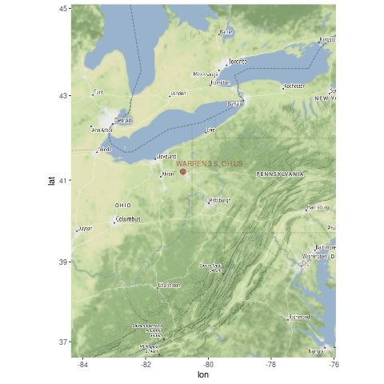

## Months with Largest Changes

[figure not shown]

## Record Temperatures

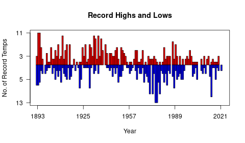

## Max. Temperature Anomaly Trend

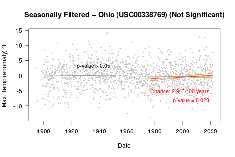

## Impacts

- Ohio’s climate is changing.
- Most of the state has warmed by about one degree (F) in the last century.
- Floods are becoming more frequent, and ice cover on the Great Lakes is forming later or melting sooner.
- In the coming decades, the state will have more extremely hot days, which may harm public health in urban areas and corn harvests in rural areas.

[EPA Snapshot](https://19january2017snapshot.epa.gov/sites/production/files/2016-09/documents/climate-change-oh.pdf)

## State Adaptation / Mitigation Plans

- Ohio has not developed a statewide adaptation plan.
- Other resources from the Adaptation Clearinghouse, which have been developed by the state and localities to help communities prepare for climate change, such as:
- Columbus, Ohio Climate Adaptation Plan December 18, 2018
- Cleveland, Ohio Climate Action Plan - 2018 Update September 21, 2018
- 2018 Green Cincinnati Plan, Ohio: Leveraging Resilience to Become a Climate Haven April 2018
- Green Cincinnati Plan April 2018
- Sustainable Cleveland 2019 2018

[Source: Georgetown Climate Center] (https://www.georgetownclimate.org/adaptation/state-information/ohio/overview.html)

## Next Steps

- Put ideas in comments how what other can do to support state efforts
- Be kind: Responding to climate change includes a complex array of ethical issues.
- “Be curious”, Ted Lasso.